# ABOUT THE PROJECT

## T20 World Cup 2022: Dataset

### The dataset contains data about all the matches from the super 12 stage to the final of the ICC Men’s T20 World Cup 2022. Below are all the features in the dataset:

- venue: The venue where the match was played
- team1: the team that batted first
- team2: the team that batted second
- stage: stage of the match (super 12, semi-final, or final)
- toss winner: the team that won the toss
- toss decision: the decision of the captain after winning the toss
- first innings score: runs scored in the first innings
- first innings wickets: the number of wickets lost in the first innings
- second innings score: runs scored in the second innings
- second innings wickets: the number of wickets lost in the second innings
- winner: the team that won the match
- won by: how the team won the match (wickets or runs)
- player of the match: the player of the match
- top scorer: the player who scored highest in the match
- highest score: the highest runs scored in the match by the player
- best bowler: the player who took the most wickets in the match
- best bowling figure: the number of wickets taken and runs given by the best bowler in the mat

## MY goal and question to be answered during the analysis are:

### Overall Tournament Performance:

- What is the average first innings score in the super 12 stage, semi-finals, and the final?
- Is there any significant difference in the average second innings score between the stages?
- Which team had the highest average first innings score throughout the tournament?

### Top Performers:

- Who were the top run-scorer and top wicket-taker of the tournament?
- What was the highest individual score by a player in a match?
- What was the best bowling figure by a player in a match?

### Team Performance:

- Which team had the most wins in each stage of the tournament?
- Which team had the highest and lowest first innings scores in a match?
- Which team had the highest and lowest second innings scores in a match?

### Player of the Match:

- Which top 5 player receive the "Player of the Match" award?

### Toss Analysis:

- What percentage of matches were won by the team that won the toss?
- Did the team winning the toss have a significant advantage in any particular stage?

### Trends and Patterns:

- The average first innings score over time as the tournament progressed.
- Comparing the distribution of second innings scores across different stages of the tournament.
- Calculating the average first innings score at each venue, to help me identify venues where teams tend to score higher or lower.
- Calculating the trend in toss decisions (batting or bowling) across different stages of the tournament

## The following are the steps that would be followed during this project

### Step 1: Gathering Data

### Step 2: Assessing data

### Step 3: Cleaning data

### Step 4: Analyzing

### Step 5: Visualization

### Step 6: Reporting

### Step 1: Gathering Data

```r
#Loading important packages
library("tidyverse")
library("ggplot2")
```

```r
#Reading the csv file into a variable t20_worldcup
t20_worldcup <- read_csv("t20-world-cup-22.csv")
```

### Step 2: Assessing data

```r
#Checking the dataset visually
t20_worldcup
```

| venue | team1 | team2 | stage | toss winner | toss decision | first innings score | first innings wickets | second innings score | second innings wickets | winner | won by | player of the match | top scorer | highest score | best bowler | best bowling figure |
| --- | --- | --- | --- | --- | --- | --- | --- | --- | --- | --- | --- | --- | --- | --- | --- | --- |
| SCG | New Zealand | Australia | Super 12 | Australia | Field | 200 | 3 | 111 | 10 | New Zealand | Runs | Devon Conway | Devon Conway | 92 | Tim Southee | 03-Jun |
| Optus Stadium | Afghanistan | England | Super 12 | England | Field | 112 | 10 | 113 | 5 | England | Wickets | Sam Curran | Ibrahim Zadran | 32 | Sam Curran | 05-Oct |
| Blundstone Arena | Ireland | Sri lanka | Super 12 | Ireland | Bat | 128 | 8 | 133 | 1 | Sri lanka | Wickets | Kusal Mendis | Kusal Mendis | 68 | Maheesh Theekshana | Feb-19 |
| MCG | Pakistan | India | Super 12 | India | Field | 159 | 8 | 160 | 6 | India | Wickets | Virat Kohli | Virat Kohli | 82 | Hardik Pandya | Mar-30 |
| Blundstone Arena | Bangladesh | Netherlands | Super 12 | Netherlands | Field | 144 | 8 | 135 | 10 | Bangladesh | Runs | Taskin Ahmed | Colin Ackermann | 62 | Taskin Ahmed | Apr-25 |
| Blundstone Arena | Zimbabwe | South Africa | Super 12 | Zimbabwe | Bat | 79 | 5 | 51 | 0 | NA | NA | NA | Quinton de Kock | 47 | Lungi Ngidi | Feb-20 |
| Optus Stadium | Sri lanka | Australia | Super 12 | Australia | Field | 157 | 6 | 158 | 3 | Australia | Wickets | Marcus Stoinis | Marcus Stoinis | 59 | Glenn Maxwell | 01-May |
| MCG | Ireland | England | Super 12 | England | Field | 157 | 10 | 105 | 5 | Ireland | Runs | Andrew Balbirnie | Andrew Balbirnie | 62 | Liam Livingstone | Mar-17 |
| MCG | New Zealand | Afghanistan | Super 12 | NA | NA | NA | NA | NA | NA | NA | NA | NA | NA | NA | NA | NA |
| SCG | South Africa | Bangladesh | Super 12 | South Africa | Bat | 205 | 5 | 101 | 10 | South Africa | Runs | Rilee Rossouw | Rilee Rossouw | 109 | Anrich Nortje | 04-Oct |
| SCG | India | Netherlands | Super 12 | India | Bat | 179 | 2 | 123 | 9 | India | Runs | Suryakumar Yadav | Virat Kohli | 62 | Bhuvneshwar Kumar | Feb-19 |
| Optus Stadium | Zimbabwe | Pakistan | Super 12 | Zimbabwe | Bat | 130 | 8 | 129 | 8 | Zimbabwe | Runs | Sikandar Raza | Shan Masood | 44 | Mohammad Wasim | Apr-24 |
| MCG | Afghanistan | Ireland | Super 12 | NA | NA | NA | NA | NA | NA | NA | NA | NA | NA | NA | NA | NA |
| MCG | Australia | England | Super 12 | NA | NA | NA | NA | NA | NA | NA | NA | NA | NA | NA | NA | NA |
| SCG | New Zealand | Sri lanka | Super 12 | New Zealand | Bat | 167 | 7 | 102 | 10 | New Zealand | Runs | Glenn Phillips | Glenn Phillips | 104 | Trent Boult | Apr-13 |
| The Gabba | Bangladesh | Zimbabwe | Super 12 | Bangladesh | Bat | 150 | 7 | 147 | 8 | Bangladesh | Runs | Taskin Ahmed | Najmul Hossain | 71 | Taskin Ahmed | Mar-19 |
| Optus Stadium | Netherlands | Pakistan | Super 12 | Netherlands | Bat | 91 | 9 | 95 | 4 | Pakistan | Wickets | Shadab Khan | Mohammad Rizwan | 49 | Shadab Khan | Mar-22 |
| Optus Stadium | India | South Africa | Super 12 | India | Bat | 133 | 9 | 137 | 5 | South Africa | Wickets | Lungi Ngidi | Suryakumar Yadav | 68 | Lungi Ngidi | Apr-29 |
| The Gabba | Australia | Ireland | Super 12 | Ireland | Field | 179 | 5 | 137 | 10 | Australia | Runs | Aaron Finch | Lorcan Tucker | 71 | Barry McCarthy | Mar-29 |
| The Gabba | Afghanistan | Sri lanka | Super 12 | Afghanistan | Bat | 144 | 8 | 148 | 4 | Sri lanka | Wickets | Wanindu Hasaranga | de Silva | 66 | Wanindu Hasaranga | Mar-13 |
| The Gabba | England | New Zealand | Super 12 | England | Bat | 179 | 6 | 159 | 6 | England | Runs | Jos Buttler | Jos Buttler | 73 | Sam Curran | Feb-26 |
| Adelaide Oval | Zimbabwe | Netherlands | Super 12 | Zimbabwe | Bat | 117 | 10 | 120 | 5 | Netherlands | Wickets | Max O'Dowd | Max O'Dowd | 52 | Paul van Meekeren | Mar-29 |
| Adelaide Oval | India | Bangladesh | Super 12 | Bangladesh | Field | 184 | 6 | 145 | 6 | India | Runs | Virat Kohli | Virat Kohli | 64 | Hasan Mahmud | Mar-47 |
| SCG | Pakistan | South Africa | Super 12 | Pakistan | Bat | 185 | 9 | 108 | 9 | Pakistan | Runs | Shadab Khan | Shadab Khan | 52 | Anrich Nortje | Apr-41 |
| Adelaide Oval | New Zealand | Ireland | Super 12 | Ireland | Field | 185 | 6 | 150 | 9 | New Zealand | Runs | Kane Williamson | Kane Williamson | 61 | Lockie Ferguson | Mar-22 |
| Adelaide Oval | Australia | Afghanistan | Super 12 | Afghanistan | Field | 168 | 8 | 164 | 7 | Australia | Runs | Glenn Maxwell | Glenn Maxwell | 54 | Naveen-ul-Haq | Mar-21 |
| SCG | Sri lanka | England | Super 12 | Sri lanka | Bat | 141 | 8 | 144 | 6 | England | Wickets | Adil Rashid | Pathum Nissanka | 67 | Mark Wood | Mar-26 |
| Adelaide Oval | Netherlands | South Africa | Super 12 | South Africa | Field | 158 | 4 | 145 | 8 | Netherlands | Runs | Colin Ackermann | Colin Ackermann | 41 | Brandon Glover | 03-Sep |
| Adelaide Oval | Bangladesh | Pakistan | Super 12 | Bangladesh | Bat | 127 | 8 | 128 | 5 | Pakistan | Wickets | Shaheen Afridi | Najmul Hossain | 54 | Shaheen Afridi | Apr-22 |
| MCG | India | Zimbabwe | Super 12 | India | Bat | 186 | 5 | 115 | 10 | India | Runs | Suryakumar Yadav | Suryakumar Yadav | 61 | Ravichandran Ashwin | Mar-22 |
| SCG | New Zealand | Pakistan | Semi-final | New Zealand | Bat | 152 | 4 | 153 | 3 | Pakistan | Wickets | Mohammad Rizwan | Mohammad Rizwan | 57 | Shaheen Afridi | Feb-24 |
| Adelaide Oval | India | England | Semi-final | England | Field | 168 | 6 | 170 | 0 | England | Wickets | Alex Hales | Alex Hales | 86 | Chris Jordan | Mar-43 |
| MCG | Pakistan | England | Final | England | Field | 137 | 8 | 138 | 5 | England | Wickets | Sam Curran | Ben Stokes | 52 | Sam Curran | 03-Dec |

```r
#Checking the dataset to know the number of observation and variable
glimpse(t20_worldcup)
```

```
Observations: 33
Variables: 17
$ venue                    <chr> "SCG", "Optus Stadium", "Blundstone Arena"...
$ team1                    <chr> "New Zealand", "Afghanistan", "Ireland", "...
$ team2                    <chr> "Australia", "England", "Sri lanka", "Indi...
$ stage                    <chr> "Super 12", "Super 12", "Super 12", "Super...
$ `toss winner`            <chr> "Australia", "England", "Ireland", "India"...
$ `toss decision`          <chr> "Field", "Field", "Bat", "Field", "Field",...
$ `first innings score`    <dbl> 200, 112, 128, 159, 144, 79, 157, 157, NA,...
$ `first innings wickets`  <dbl> 3, 10, 8, 8, 8, 5, 6, 10, NA, 5, 2, 8, NA,...
$ `second innings score`   <dbl> 111, 113, 133, 160, 135, 51, 158, 105, NA,...
$ `second innings wickets` <dbl> 10, 5, 1, 6, 10, 0, 3, 5, NA, 10, 9, 8, NA...
$ winner                   <chr> "New Zealand", "England", "Sri lanka", "In...
$ `won by`                 <chr> "Runs", "Wickets", "Wickets", "Wickets", "...
$ `player of the match`    <chr> "Devon Conway", "Sam Curran", "Kusal Mendi...
$ `top scorer`             <chr> "Devon Conway", "Ibrahim Zadran", "Kusal M...
$ `highest score`          <dbl> 92, 32, 68, 82, 62, 47, 59, 62, NA, 109, 6...
$ `best bowler`            <chr> "Tim Southee", "Sam Curran", "Maheesh Thee...
$ `best bowling figure`    <chr> "03-Jun", "05-Oct", "Feb-19", "Mar-30", "A...
```

```r
#Checking for the summary statistics of  the dataset
summary(t20_worldcup)
```

```
    venue              team1              team2              stage
 Length:33          Length:33          Length:33          Length:33
 Class :character   Class :character   Class :character   Class :character
 Mode  :character   Mode  :character   Mode  :character   Mode  :character




 toss winner        toss decision      first innings score
 Length:33          Length:33          Min.   : 79.0
 Class :character   Class :character   1st Qu.:134.0
 Mode  :character   Mode  :character   Median :157.0
                                       Mean   :153.4
                                       3rd Qu.:179.0
                                       Max.   :205.0
                                       NA's   :3
 first innings wickets second innings score second innings wickets
 Min.   : 2.000        Min.   : 51.0        Min.   : 0.000
 1st Qu.: 5.250        1st Qu.:113.5        1st Qu.: 5.000
 Median : 7.500        Median :136.0        Median : 6.000
 Mean   : 6.867        Mean   :130.8        Mean   : 6.233
 3rd Qu.: 8.000        3rd Qu.:147.8        3rd Qu.: 9.000
 Max.   :10.000        Max.   :170.0        Max.   :10.000
 NA's   :3             NA's   :3            NA's   :3
    winner             won by          player of the match  top scorer
 Length:33          Length:33          Length:33           Length:33
 Class :character   Class :character   Class :character    Class :character
 Mode  :character   Mode  :character   Mode  :character    Mode  :character




 highest score    best bowler        best bowling figure
 Min.   : 32.00   Length:33          Length:33
 1st Qu.: 52.50   Class :character   Class :character
 Median : 62.00   Mode  :character   Mode  :character
 Mean   : 64.07
 3rd Qu.: 70.25
 Max.   :109.00
 NA's   :3
```

```r
#Checking for any missing Values
any(is.na(t20_worldcup))
```

TRUE

```r
# finding the location of missing values
which(is.na(t20_worldcup))
```

1. 141

2. 145

3. 146

4. 174

5. 178

6. 179

7. 207

8. 211

9. 212

10. 240

11. 244

12. 245

13. 273

14. 277

15. 278

16. 306

17. 310

18. 311

19. 336

20. 339

21. 343

22. 344

23. 369

24. 372

25. 376

26. 377

27. 402

28. 405

29. 409

30. 410

31. 438

32. 442

33. 443

34. 471

35. 475

36. 476

37. 504

38. 508

39. 509

40. 537

41. 541

42. 542

```r
#counting the total missing values
sum(is.na(t20_worldcup))
```

42

```r
#finding the location of missing values column wise
sapply(t20_worldcup, function(x) which(is.na(x)))
```

**$venue**

**$team1**

**$team2**

**$stage**

**$`toss winner`**

1. 9

2. 13

3. 14

**$`toss decision`**

1. 9

2. 13

3. 14

**$`first innings score`**

1. 9

2. 13

3. 14

**$`first innings wickets`**

1. 9

2. 13

3. 14

**$`second innings score`**

1. 9

2. 13

3. 14

**$`second innings wickets`**

1. 9

2. 13

3. 14

**$winner**

1. 6

2. 9

3. 13

4. 14

**$`won by`**

1. 6

2. 9

3. 13

4. 14

**$`player of the match`**

1. 6

2. 9

3. 13

4. 14

**$`top scorer`**

1. 9

2. 13

3. 14

**$`highest score`**

1. 9

2. 13

3. 14

**$`best bowler`**

1. 9

2. 13

3. 14

**$`best bowling figure`**

1. 9

2. 13

3. 14

```r
#counting the missing values by column wise
sapply(t20_worldcup, function(x) sum(is.na(x)))
```

**venue**

0

**team1**

0

**team2**

0

**stage**

0

**toss winner**

3

**toss decision**

3

**first innings score**

3

**first innings wickets**

3

**second innings score**

3

**second innings wickets**

3

**winner**

4

**won by**

4

**player of the match**

4

**top scorer**

3

**highest score**

3

**best bowler**

3

**best bowling figure**

3

```r
#Checking for duplicates
sum(duplicated(t20_worldcup))
```

0

### After assessing our tables based on quality and tidiness it was observed that :

- We have some missing data in dataset which can be dropped due to the observation from the assessment
- Also the column names should be properly renamed with underscore instead of having spaces in between the names
- Then the last column named best_bowling_figure should be dropped, because it contains a date instead of figures
- Lastly a new column will be created to calculate the average_best_bowling_figure(More like saying the best_bowling_figure)

### Step 3: Cleaning data

```r
#First we make the copy of the dataset before cleaning
t20_worldcup_copy <- t20_worldcup
```

```r
#Removing the rows with NA
t20_worldcup_copy <- t20_worldcup_copy %>% drop_na()

#Checking if row where properly removed
sum(is.na(t20_worldcup_copy))
```

0

```r
#Another check visually
t20_worldcup_copy
```

| venue | team1 | team2 | stage | toss winner | toss decision | first innings score | first innings wickets | second innings score | second innings wickets | winner | won by | player of the match | top scorer | highest score | best bowler | best bowling figure |
| --- | --- | --- | --- | --- | --- | --- | --- | --- | --- | --- | --- | --- | --- | --- | --- | --- |
| SCG | New Zealand | Australia | Super 12 | Australia | Field | 200 | 3 | 111 | 10 | New Zealand | Runs | Devon Conway | Devon Conway | 92 | Tim Southee | 03-Jun |
| Optus Stadium | Afghanistan | England | Super 12 | England | Field | 112 | 10 | 113 | 5 | England | Wickets | Sam Curran | Ibrahim Zadran | 32 | Sam Curran | 05-Oct |
| Blundstone Arena | Ireland | Sri lanka | Super 12 | Ireland | Bat | 128 | 8 | 133 | 1 | Sri lanka | Wickets | Kusal Mendis | Kusal Mendis | 68 | Maheesh Theekshana | Feb-19 |
| MCG | Pakistan | India | Super 12 | India | Field | 159 | 8 | 160 | 6 | India | Wickets | Virat Kohli | Virat Kohli | 82 | Hardik Pandya | Mar-30 |
| Blundstone Arena | Bangladesh | Netherlands | Super 12 | Netherlands | Field | 144 | 8 | 135 | 10 | Bangladesh | Runs | Taskin Ahmed | Colin Ackermann | 62 | Taskin Ahmed | Apr-25 |
| Optus Stadium | Sri lanka | Australia | Super 12 | Australia | Field | 157 | 6 | 158 | 3 | Australia | Wickets | Marcus Stoinis | Marcus Stoinis | 59 | Glenn Maxwell | 01-May |
| MCG | Ireland | England | Super 12 | England | Field | 157 | 10 | 105 | 5 | Ireland | Runs | Andrew Balbirnie | Andrew Balbirnie | 62 | Liam Livingstone | Mar-17 |
| SCG | South Africa | Bangladesh | Super 12 | South Africa | Bat | 205 | 5 | 101 | 10 | South Africa | Runs | Rilee Rossouw | Rilee Rossouw | 109 | Anrich Nortje | 04-Oct |
| SCG | India | Netherlands | Super 12 | India | Bat | 179 | 2 | 123 | 9 | India | Runs | Suryakumar Yadav | Virat Kohli | 62 | Bhuvneshwar Kumar | Feb-19 |
| Optus Stadium | Zimbabwe | Pakistan | Super 12 | Zimbabwe | Bat | 130 | 8 | 129 | 8 | Zimbabwe | Runs | Sikandar Raza | Shan Masood | 44 | Mohammad Wasim | Apr-24 |
| SCG | New Zealand | Sri lanka | Super 12 | New Zealand | Bat | 167 | 7 | 102 | 10 | New Zealand | Runs | Glenn Phillips | Glenn Phillips | 104 | Trent Boult | Apr-13 |
| The Gabba | Bangladesh | Zimbabwe | Super 12 | Bangladesh | Bat | 150 | 7 | 147 | 8 | Bangladesh | Runs | Taskin Ahmed | Najmul Hossain | 71 | Taskin Ahmed | Mar-19 |
| Optus Stadium | Netherlands | Pakistan | Super 12 | Netherlands | Bat | 91 | 9 | 95 | 4 | Pakistan | Wickets | Shadab Khan | Mohammad Rizwan | 49 | Shadab Khan | Mar-22 |
| Optus Stadium | India | South Africa | Super 12 | India | Bat | 133 | 9 | 137 | 5 | South Africa | Wickets | Lungi Ngidi | Suryakumar Yadav | 68 | Lungi Ngidi | Apr-29 |
| The Gabba | Australia | Ireland | Super 12 | Ireland | Field | 179 | 5 | 137 | 10 | Australia | Runs | Aaron Finch | Lorcan Tucker | 71 | Barry McCarthy | Mar-29 |
| The Gabba | Afghanistan | Sri lanka | Super 12 | Afghanistan | Bat | 144 | 8 | 148 | 4 | Sri lanka | Wickets | Wanindu Hasaranga | de Silva | 66 | Wanindu Hasaranga | Mar-13 |
| The Gabba | England | New Zealand | Super 12 | England | Bat | 179 | 6 | 159 | 6 | England | Runs | Jos Buttler | Jos Buttler | 73 | Sam Curran | Feb-26 |
| Adelaide Oval | Zimbabwe | Netherlands | Super 12 | Zimbabwe | Bat | 117 | 10 | 120 | 5 | Netherlands | Wickets | Max O'Dowd | Max O'Dowd | 52 | Paul van Meekeren | Mar-29 |
| Adelaide Oval | India | Bangladesh | Super 12 | Bangladesh | Field | 184 | 6 | 145 | 6 | India | Runs | Virat Kohli | Virat Kohli | 64 | Hasan Mahmud | Mar-47 |
| SCG | Pakistan | South Africa | Super 12 | Pakistan | Bat | 185 | 9 | 108 | 9 | Pakistan | Runs | Shadab Khan | Shadab Khan | 52 | Anrich Nortje | Apr-41 |
| Adelaide Oval | New Zealand | Ireland | Super 12 | Ireland | Field | 185 | 6 | 150 | 9 | New Zealand | Runs | Kane Williamson | Kane Williamson | 61 | Lockie Ferguson | Mar-22 |
| Adelaide Oval | Australia | Afghanistan | Super 12 | Afghanistan | Field | 168 | 8 | 164 | 7 | Australia | Runs | Glenn Maxwell | Glenn Maxwell | 54 | Naveen-ul-Haq | Mar-21 |
| SCG | Sri lanka | England | Super 12 | Sri lanka | Bat | 141 | 8 | 144 | 6 | England | Wickets | Adil Rashid | Pathum Nissanka | 67 | Mark Wood | Mar-26 |
| Adelaide Oval | Netherlands | South Africa | Super 12 | South Africa | Field | 158 | 4 | 145 | 8 | Netherlands | Runs | Colin Ackermann | Colin Ackermann | 41 | Brandon Glover | 03-Sep |
| Adelaide Oval | Bangladesh | Pakistan | Super 12 | Bangladesh | Bat | 127 | 8 | 128 | 5 | Pakistan | Wickets | Shaheen Afridi | Najmul Hossain | 54 | Shaheen Afridi | Apr-22 |
| MCG | India | Zimbabwe | Super 12 | India | Bat | 186 | 5 | 115 | 10 | India | Runs | Suryakumar Yadav | Suryakumar Yadav | 61 | Ravichandran Ashwin | Mar-22 |
| SCG | New Zealand | Pakistan | Semi-final | New Zealand | Bat | 152 | 4 | 153 | 3 | Pakistan | Wickets | Mohammad Rizwan | Mohammad Rizwan | 57 | Shaheen Afridi | Feb-24 |
| Adelaide Oval | India | England | Semi-final | England | Field | 168 | 6 | 170 | 0 | England | Wickets | Alex Hales | Alex Hales | 86 | Chris Jordan | Mar-43 |
| MCG | Pakistan | England | Final | England | Field | 137 | 8 | 138 | 5 | England | Wickets | Sam Curran | Ben Stokes | 52 | Sam Curran | 03-Dec |

```r
#Renaming Columns
t20_worldcup_copy <- t20_worldcup_copy%>%
rename(toss_winner = "toss winner",
       toss_decision = "toss decision",
       first_innings_score = "first innings score",
       first_innings_wickets = "first innings wickets",
       second_innings_score = "second innings score",
       second_innings_wickets = "second innings wickets",
       won_by = "won by",
       player_of_the_match = "player of the match",
       top_scorer = "top scorer",
       highest_score = "highest score",
       best_bowler = "best bowler",
       best_bowling_figure = "best bowling figure")

#Checking the column names
colnames(t20_worldcup_copy)
```

1. 'venue'

2. 'team1'

3. 'team2'

4. 'stage'

5. 'toss_winner'

6. 'toss_decision'

7. 'first_innings_score'

8. 'first_innings_wickets'

9. 'second_innings_score'

10. 'second_innings_wickets'

11. 'winner'

12. 'won_by'

13. 'player_of_the_match'

14. 'top_scorer'

15. 'highest_score'

16. 'best_bowler'

17. 'best_bowling_figure'

```r
# Dropping best_bowling_figure column by using the subset function which help me keep the columns i need.
t20_worldcup_copy <- subset(t20_worldcup_copy, select = c(venue, team1, team2, stage,
                                toss_winner, toss_decision, first_innings_score, first_innings_wickets,
                                second_innings_score, second_innings_wickets, winner, won_by,
                                player_of_the_match, top_scorer, highest_score, best_bowler))
#Checking our dataset
t20_worldcup_copy
```

| venue | team1 | team2 | stage | toss_winner | toss_decision | first_innings_score | first_innings_wickets | second_innings_score | second_innings_wickets | winner | won_by | player_of_the_match | top_scorer | highest_score | best_bowler |
| --- | --- | --- | --- | --- | --- | --- | --- | --- | --- | --- | --- | --- | --- | --- | --- |
| SCG | New Zealand | Australia | Super 12 | Australia | Field | 200 | 3 | 111 | 10 | New Zealand | Runs | Devon Conway | Devon Conway | 92 | Tim Southee |
| Optus Stadium | Afghanistan | England | Super 12 | England | Field | 112 | 10 | 113 | 5 | England | Wickets | Sam Curran | Ibrahim Zadran | 32 | Sam Curran |
| Blundstone Arena | Ireland | Sri lanka | Super 12 | Ireland | Bat | 128 | 8 | 133 | 1 | Sri lanka | Wickets | Kusal Mendis | Kusal Mendis | 68 | Maheesh Theekshana |
| MCG | Pakistan | India | Super 12 | India | Field | 159 | 8 | 160 | 6 | India | Wickets | Virat Kohli | Virat Kohli | 82 | Hardik Pandya |
| Blundstone Arena | Bangladesh | Netherlands | Super 12 | Netherlands | Field | 144 | 8 | 135 | 10 | Bangladesh | Runs | Taskin Ahmed | Colin Ackermann | 62 | Taskin Ahmed |
| Optus Stadium | Sri lanka | Australia | Super 12 | Australia | Field | 157 | 6 | 158 | 3 | Australia | Wickets | Marcus Stoinis | Marcus Stoinis | 59 | Glenn Maxwell |
| MCG | Ireland | England | Super 12 | England | Field | 157 | 10 | 105 | 5 | Ireland | Runs | Andrew Balbirnie | Andrew Balbirnie | 62 | Liam Livingstone |
| SCG | South Africa | Bangladesh | Super 12 | South Africa | Bat | 205 | 5 | 101 | 10 | South Africa | Runs | Rilee Rossouw | Rilee Rossouw | 109 | Anrich Nortje |
| SCG | India | Netherlands | Super 12 | India | Bat | 179 | 2 | 123 | 9 | India | Runs | Suryakumar Yadav | Virat Kohli | 62 | Bhuvneshwar Kumar |
| Optus Stadium | Zimbabwe | Pakistan | Super 12 | Zimbabwe | Bat | 130 | 8 | 129 | 8 | Zimbabwe | Runs | Sikandar Raza | Shan Masood | 44 | Mohammad Wasim |
| SCG | New Zealand | Sri lanka | Super 12 | New Zealand | Bat | 167 | 7 | 102 | 10 | New Zealand | Runs | Glenn Phillips | Glenn Phillips | 104 | Trent Boult |
| The Gabba | Bangladesh | Zimbabwe | Super 12 | Bangladesh | Bat | 150 | 7 | 147 | 8 | Bangladesh | Runs | Taskin Ahmed | Najmul Hossain | 71 | Taskin Ahmed |
| Optus Stadium | Netherlands | Pakistan | Super 12 | Netherlands | Bat | 91 | 9 | 95 | 4 | Pakistan | Wickets | Shadab Khan | Mohammad Rizwan | 49 | Shadab Khan |
| Optus Stadium | India | South Africa | Super 12 | India | Bat | 133 | 9 | 137 | 5 | South Africa | Wickets | Lungi Ngidi | Suryakumar Yadav | 68 | Lungi Ngidi |
| The Gabba | Australia | Ireland | Super 12 | Ireland | Field | 179 | 5 | 137 | 10 | Australia | Runs | Aaron Finch | Lorcan Tucker | 71 | Barry McCarthy |
| The Gabba | Afghanistan | Sri lanka | Super 12 | Afghanistan | Bat | 144 | 8 | 148 | 4 | Sri lanka | Wickets | Wanindu Hasaranga | de Silva | 66 | Wanindu Hasaranga |
| The Gabba | England | New Zealand | Super 12 | England | Bat | 179 | 6 | 159 | 6 | England | Runs | Jos Buttler | Jos Buttler | 73 | Sam Curran |
| Adelaide Oval | Zimbabwe | Netherlands | Super 12 | Zimbabwe | Bat | 117 | 10 | 120 | 5 | Netherlands | Wickets | Max O'Dowd | Max O'Dowd | 52 | Paul van Meekeren |
| Adelaide Oval | India | Bangladesh | Super 12 | Bangladesh | Field | 184 | 6 | 145 | 6 | India | Runs | Virat Kohli | Virat Kohli | 64 | Hasan Mahmud |
| SCG | Pakistan | South Africa | Super 12 | Pakistan | Bat | 185 | 9 | 108 | 9 | Pakistan | Runs | Shadab Khan | Shadab Khan | 52 | Anrich Nortje |
| Adelaide Oval | New Zealand | Ireland | Super 12 | Ireland | Field | 185 | 6 | 150 | 9 | New Zealand | Runs | Kane Williamson | Kane Williamson | 61 | Lockie Ferguson |
| Adelaide Oval | Australia | Afghanistan | Super 12 | Afghanistan | Field | 168 | 8 | 164 | 7 | Australia | Runs | Glenn Maxwell | Glenn Maxwell | 54 | Naveen-ul-Haq |
| SCG | Sri lanka | England | Super 12 | Sri lanka | Bat | 141 | 8 | 144 | 6 | England | Wickets | Adil Rashid | Pathum Nissanka | 67 | Mark Wood |
| Adelaide Oval | Netherlands | South Africa | Super 12 | South Africa | Field | 158 | 4 | 145 | 8 | Netherlands | Runs | Colin Ackermann | Colin Ackermann | 41 | Brandon Glover |
| Adelaide Oval | Bangladesh | Pakistan | Super 12 | Bangladesh | Bat | 127 | 8 | 128 | 5 | Pakistan | Wickets | Shaheen Afridi | Najmul Hossain | 54 | Shaheen Afridi |
| MCG | India | Zimbabwe | Super 12 | India | Bat | 186 | 5 | 115 | 10 | India | Runs | Suryakumar Yadav | Suryakumar Yadav | 61 | Ravichandran Ashwin |
| SCG | New Zealand | Pakistan | Semi-final | New Zealand | Bat | 152 | 4 | 153 | 3 | Pakistan | Wickets | Mohammad Rizwan | Mohammad Rizwan | 57 | Shaheen Afridi |
| Adelaide Oval | India | England | Semi-final | England | Field | 168 | 6 | 170 | 0 | England | Wickets | Alex Hales | Alex Hales | 86 | Chris Jordan |
| MCG | Pakistan | England | Final | England | Field | 137 | 8 | 138 | 5 | England | Wickets | Sam Curran | Ben Stokes | 52 | Sam Curran |

```r
# Calculating the total_innings_score by adding first_innings_score and second_innings_score
t20_worldcup_copy$total_innings_score <- t20_worldcup_copy$first_innings_score + t20_worldcup_copy$second_innings_score

# Calculating the total_innings_wickets by adding the first_innings_wickets and second_innings_wickets
t20_worldcup_copy$total_innings_wickets <- t20_worldcup_copy$first_innings_wickets + t20_worldcup_copy$second_innings_wickets

#Adding the averages together to get our best_bowling_figure
t20_worldcup_copy$average_best_bowling_figure = t20_worldcup_copy$total_innings_score / t20_worldcup_copy$total_innings_wickets


#Checking Our result
t20_worldcup_copy
```

| venue | team1 | team2 | stage | toss_winner | toss_decision | first_innings_score | first_innings_wickets | second_innings_score | second_innings_wickets | winner | won_by | player_of_the_match | top_scorer | highest_score | best_bowler | total_innings_score | total_innings_wickets | average_best_bowling_figure |
| --- | --- | --- | --- | --- | --- | --- | --- | --- | --- | --- | --- | --- | --- | --- | --- | --- | --- | --- |
| SCG | New Zealand | Australia | Super 12 | Australia | Field | 200 | 3 | 111 | 10 | New Zealand | Runs | Devon Conway | Devon Conway | 92 | Tim Southee | 311 | 13 | 23.92308 |
| Optus Stadium | Afghanistan | England | Super 12 | England | Field | 112 | 10 | 113 | 5 | England | Wickets | Sam Curran | Ibrahim Zadran | 32 | Sam Curran | 225 | 15 | 15.00000 |
| Blundstone Arena | Ireland | Sri lanka | Super 12 | Ireland | Bat | 128 | 8 | 133 | 1 | Sri lanka | Wickets | Kusal Mendis | Kusal Mendis | 68 | Maheesh Theekshana | 261 | 9 | 29.00000 |
| MCG | Pakistan | India | Super 12 | India | Field | 159 | 8 | 160 | 6 | India | Wickets | Virat Kohli | Virat Kohli | 82 | Hardik Pandya | 319 | 14 | 22.78571 |
| Blundstone Arena | Bangladesh | Netherlands | Super 12 | Netherlands | Field | 144 | 8 | 135 | 10 | Bangladesh | Runs | Taskin Ahmed | Colin Ackermann | 62 | Taskin Ahmed | 279 | 18 | 15.50000 |
| Optus Stadium | Sri lanka | Australia | Super 12 | Australia | Field | 157 | 6 | 158 | 3 | Australia | Wickets | Marcus Stoinis | Marcus Stoinis | 59 | Glenn Maxwell | 315 | 9 | 35.00000 |
| MCG | Ireland | England | Super 12 | England | Field | 157 | 10 | 105 | 5 | Ireland | Runs | Andrew Balbirnie | Andrew Balbirnie | 62 | Liam Livingstone | 262 | 15 | 17.46667 |
| SCG | South Africa | Bangladesh | Super 12 | South Africa | Bat | 205 | 5 | 101 | 10 | South Africa | Runs | Rilee Rossouw | Rilee Rossouw | 109 | Anrich Nortje | 306 | 15 | 20.40000 |
| SCG | India | Netherlands | Super 12 | India | Bat | 179 | 2 | 123 | 9 | India | Runs | Suryakumar Yadav | Virat Kohli | 62 | Bhuvneshwar Kumar | 302 | 11 | 27.45455 |
| Optus Stadium | Zimbabwe | Pakistan | Super 12 | Zimbabwe | Bat | 130 | 8 | 129 | 8 | Zimbabwe | Runs | Sikandar Raza | Shan Masood | 44 | Mohammad Wasim | 259 | 16 | 16.18750 |
| SCG | New Zealand | Sri lanka | Super 12 | New Zealand | Bat | 167 | 7 | 102 | 10 | New Zealand | Runs | Glenn Phillips | Glenn Phillips | 104 | Trent Boult | 269 | 17 | 15.82353 |
| The Gabba | Bangladesh | Zimbabwe | Super 12 | Bangladesh | Bat | 150 | 7 | 147 | 8 | Bangladesh | Runs | Taskin Ahmed | Najmul Hossain | 71 | Taskin Ahmed | 297 | 15 | 19.80000 |
| Optus Stadium | Netherlands | Pakistan | Super 12 | Netherlands | Bat | 91 | 9 | 95 | 4 | Pakistan | Wickets | Shadab Khan | Mohammad Rizwan | 49 | Shadab Khan | 186 | 13 | 14.30769 |
| Optus Stadium | India | South Africa | Super 12 | India | Bat | 133 | 9 | 137 | 5 | South Africa | Wickets | Lungi Ngidi | Suryakumar Yadav | 68 | Lungi Ngidi | 270 | 14 | 19.28571 |
| The Gabba | Australia | Ireland | Super 12 | Ireland | Field | 179 | 5 | 137 | 10 | Australia | Runs | Aaron Finch | Lorcan Tucker | 71 | Barry McCarthy | 316 | 15 | 21.06667 |
| The Gabba | Afghanistan | Sri lanka | Super 12 | Afghanistan | Bat | 144 | 8 | 148 | 4 | Sri lanka | Wickets | Wanindu Hasaranga | de Silva | 66 | Wanindu Hasaranga | 292 | 12 | 24.33333 |
| The Gabba | England | New Zealand | Super 12 | England | Bat | 179 | 6 | 159 | 6 | England | Runs | Jos Buttler | Jos Buttler | 73 | Sam Curran | 338 | 12 | 28.16667 |
| Adelaide Oval | Zimbabwe | Netherlands | Super 12 | Zimbabwe | Bat | 117 | 10 | 120 | 5 | Netherlands | Wickets | Max O'Dowd | Max O'Dowd | 52 | Paul van Meekeren | 237 | 15 | 15.80000 |
| Adelaide Oval | India | Bangladesh | Super 12 | Bangladesh | Field | 184 | 6 | 145 | 6 | India | Runs | Virat Kohli | Virat Kohli | 64 | Hasan Mahmud | 329 | 12 | 27.41667 |
| SCG | Pakistan | South Africa | Super 12 | Pakistan | Bat | 185 | 9 | 108 | 9 | Pakistan | Runs | Shadab Khan | Shadab Khan | 52 | Anrich Nortje | 293 | 18 | 16.27778 |
| Adelaide Oval | New Zealand | Ireland | Super 12 | Ireland | Field | 185 | 6 | 150 | 9 | New Zealand | Runs | Kane Williamson | Kane Williamson | 61 | Lockie Ferguson | 335 | 15 | 22.33333 |
| Adelaide Oval | Australia | Afghanistan | Super 12 | Afghanistan | Field | 168 | 8 | 164 | 7 | Australia | Runs | Glenn Maxwell | Glenn Maxwell | 54 | Naveen-ul-Haq | 332 | 15 | 22.13333 |
| SCG | Sri lanka | England | Super 12 | Sri lanka | Bat | 141 | 8 | 144 | 6 | England | Wickets | Adil Rashid | Pathum Nissanka | 67 | Mark Wood | 285 | 14 | 20.35714 |
| Adelaide Oval | Netherlands | South Africa | Super 12 | South Africa | Field | 158 | 4 | 145 | 8 | Netherlands | Runs | Colin Ackermann | Colin Ackermann | 41 | Brandon Glover | 303 | 12 | 25.25000 |
| Adelaide Oval | Bangladesh | Pakistan | Super 12 | Bangladesh | Bat | 127 | 8 | 128 | 5 | Pakistan | Wickets | Shaheen Afridi | Najmul Hossain | 54 | Shaheen Afridi | 255 | 13 | 19.61538 |
| MCG | India | Zimbabwe | Super 12 | India | Bat | 186 | 5 | 115 | 10 | India | Runs | Suryakumar Yadav | Suryakumar Yadav | 61 | Ravichandran Ashwin | 301 | 15 | 20.06667 |
| SCG | New Zealand | Pakistan | Semi-final | New Zealand | Bat | 152 | 4 | 153 | 3 | Pakistan | Wickets | Mohammad Rizwan | Mohammad Rizwan | 57 | Shaheen Afridi | 305 | 7 | 43.57143 |
| Adelaide Oval | India | England | Semi-final | England | Field | 168 | 6 | 170 | 0 | England | Wickets | Alex Hales | Alex Hales | 86 | Chris Jordan | 338 | 6 | 56.33333 |
| MCG | Pakistan | England | Final | England | Field | 137 | 8 | 138 | 5 | England | Wickets | Sam Curran | Ben Stokes | 52 | Sam Curran | 275 | 13 | 21.15385 |

### Step 4: Analyzing

### Overall Tournament Performance

- Calculating average first innings score by stage

```r
#Calculating the average first innings score by stage
average_first_innings_score <- t20_worldcup_copy %>%
group_by(stage) %>%
summarise(average_score = mean(first_innings_score))%>%
arrange(desc(average_score))

average_first_innings_score
```

| stage | average_score |
| --- | --- |
| Semi-final | 160.0000 |
| Super 12 | 156.3462 |
| Final | 137.0000 |

- Is there any significant difference in the average second innings score between the stages?

```r
# Testing for significant difference in second innings scores between stages
anova_result <- aov(second_innings_score ~ stage, data = t20_worldcup_copy)
summary(anova_result)
```

```
            Df Sum Sq Mean Sq F value Pr(>F)
stage        2   1722   861.0   2.119   0.14
Residuals   26  10565   406.4
```

### Result

###### The ANOVA results suggest that there are no statistically significant differences in the second innings scores across the different stages of the T20 World Cup matches as there is no strong evidence to reject the null hypothesis which is also indicated by the relatively large p-value (0.14) for the stage variable.

- Which team had the highest average first innings score throughout the tournament?

```r
# Calculating the average first innings score for team1
team1_average_scores <- t20_worldcup_copy %>%
  group_by(team1) %>%
  summarize(average_first_innings_score = mean(first_innings_score))

# Calculating the average first innings score for team2
team2_average_scores <- t20_worldcup_copy %>%
  group_by(team2) %>%
  summarize(average_first_innings_score = mean(first_innings_score))

# Merging the results for team1 and team2
average_scores_combined <- bind_rows(
  team1 = team1_average_scores,
  team2 = team2_average_scores
)

# Finding the team  with the highest average first innings score
team_with_highest_average <- average_scores_combined %>%
  arrange(desc(average_first_innings_score)) %>%
  head(1)

# Print the result
cat("Team with the highest average first innings score:", team_with_highest_average$team1, "\n")
cat("Average first innings score:", team_with_highest_average$average_first_innings_score, "\n")
```

```
Team with the highest average first innings score: South Africa
Average first innings score: 205
```

### Top Performers:

- Who were the top run-scorer and top wicket-taker of the tournament?

```r
# Top run_scorer of the tournament
top_scorer <- t20_worldcup_copy %>%
group_by(player_of_the_match) %>%
summarise(total_runs = sum(highest_score))%>%
arrange(desc(total_runs))%>%
head(1)

#Top wicket_taker of the tournament
top_bowler <- t20_worldcup_copy %>%
group_by(best_bowler) %>%
summarise(total_wickets = sum(first_innings_wickets,second_innings_wickets))%>%
arrange(desc(total_wickets))%>%
head(1)


# Print the result
cat("Top run-scorer of the tournament is:", top_scorer$player_of_the_match, "\n")
cat("With a score of :", top_scorer$total_runs, "\n")
cat("Top wicket-taker of the tournament is :", top_bowler$best_bowler, "\n")
cat("With a score of :", top_bowler$total_wickets, "\n")
```

```
Top run-scorer of the tournament is: Virat Kohli
With a score of : 146
Top wicket-taker of the tournament is : Sam Curran
With a score of : 40
```

- What was the highest individual score by a player in a match?

```r
# Calculating the highest individual score
highest_individual_score <- t20_worldcup_copy%>%
group_by(top_scorer)%>%
arrange(desc(highest_score)) %>%
head(1)

# Print the result
cat("Highest individual score by a player in a match:", highest_individual_score$highest_score, "\n")
cat("And the player is :", highest_individual_score$top_scorer, "\n")
```

```
Highest individual score by a player in a match: 109
And the player is : Rilee Rossouw
```

- What was the best bowling figure by a player in a match?

```r
#Calculating the best average bowling figure by a player in a match
best_bowling_figure <- t20_worldcup_copy %>%
group_by(best_bowler)%>%
arrange(average_best_bowling_figure) %>%
head(1)

cat("Best average bowling figure by a player in a match:", best_bowling_figure$average_best_bowling_figure, "\n")
cat("And the player is :", best_bowling_figure$best_bowler, "\n")
```

```
Best average bowling figure by a player in a match: 14.30769
And the player is : Shadab Khan
```

### Team Performance:

- Which team had the most wins in each stage of the tournament?

```r
#Calculating the team with the most wins in each stage
team_with_most_wins <- t20_worldcup_copy %>%
  group_by(stage, winner) %>%
  summarise(matches_won = n()) %>%
  arrange(stage, desc(matches_won)) %>%
  slice(1)

team_with_most_wins
```

| stage | winner | matches_won |
| --- | --- | --- |
| Final | England | 1 |
| Semi-final | England | 1 |
| Super 12 | India | 4 |

- Which team had the highest and lowest first innings scores in a match?

```r
#Calculate the maximum and minimum first innings scores for team1
team1_max_and_min_scores <- t20_worldcup_copy %>%
  group_by(team1) %>%
  summarize(max_first_innings_score = max(first_innings_score),
            min_first_innings_score = min(first_innings_score))

# Calculate the maximum and minimum first innings scores for team2
team2_max_and_min_scores <- t20_worldcup_copy %>%
  group_by(team2) %>%
  summarize(max_first_innings_score = max(first_innings_score),
            min_first_innings_score = min(first_innings_score))

# Merge the results for team1 and team2
max_and_min_scores_combined <- bind_rows(
  team1 = team1_max_and_min_scores,
  team2 = team2_max_and_min_scores
)

# Find the team (either team1 or team2) with the highest and lowest first innings scores
team_with_highest_score <- max_and_min_scores_combined %>%
  arrange(desc(max_first_innings_score)) %>%
  head(1)

team_with_lowest_score <- max_and_min_scores_combined %>%
  arrange(min_first_innings_score) %>%
  head(1)

# Print the results
cat("Team with the highest first innings score:", team_with_highest_score$team1, "\n")
cat("Highest first innings score:", team_with_highest_score$max_first_innings_score, "\n")

cat("Team with the lowest first innings score:", team_with_lowest_score$team1, "\n")
cat("Lowest first innings score:", team_with_lowest_score$min_first_innings_score, "\n")
```

```
Team with the highest first innings score: South Africa
Highest first innings score: 205
Team with the lowest first innings score: Netherlands
Lowest first innings score: 91
```

- Which team had the highest and lowest second innings scores in a match?

```r
#Calculating the maximum and minimum first innings scores for team1
team1_max_and_min_scores <- t20_worldcup_copy %>%
  group_by(team1) %>%
  summarize(max_first_innings_score = max(second_innings_score),
            min_first_innings_score = min(second_innings_score))

# Calculating the maximum and minimum first innings scores for team2
team2_max_and_min_scores <- t20_worldcup_copy %>%
  group_by(team2) %>%
  summarize(max_first_innings_score = max(second_innings_score),
            min_first_innings_score = min(second_innings_score))

# Merging the results for team1 and team2
max_and_min_scores_combined <- bind_rows(
  team1 = team1_max_and_min_scores,
  team2 = team2_max_and_min_scores
)

# Finding the team with the highest and lowest second innings scores
team_with_highest_score <- max_and_min_scores_combined %>%
  arrange(desc(max_first_innings_score)) %>%
  head(1)

team_with_lowest_score <- max_and_min_scores_combined %>%
  arrange(min_first_innings_score) %>%
  head(1)

# Print the results
cat("Team with the highest second innings score:", team_with_highest_score$team1, "\n")
cat("Highest first innings score:", team_with_highest_score$max_first_innings_score, "\n")

cat("Team with the lowest second innings score:", team_with_lowest_score$team1, "\n")
cat("Lowest first innings score:", team_with_lowest_score$min_first_innings_score, "\n")
```

```
Team with the highest second innings score: India
Highest first innings score: 170
Team with the lowest second innings score: Netherlands
Lowest first innings score: 95
```

### Player of the Match:

- Which top 5 player receive the "Player of the Match" award?

```r
# Counting the number of times each player received "Player of the Match" award
player_of_the_match <- t20_worldcup_copy %>%
group_by(player_of_the_match) %>%
summarise(count = n())%>%
arrange(desc(count))%>%


head(5)
player_of_the_match
```

| player_of_the_match | count |
| --- | --- |
| Sam Curran | 2 |
| Shadab Khan | 2 |
| Suryakumar Yadav | 2 |
| Taskin Ahmed | 2 |
| Virat Kohli | 2 |

### Toss Analysis:

- What percentage of matches were won by the team that won the toss?
- Did the team winning the toss have a significant advantage in any particular stage?

```r
# Calculating the percentage of matches won by the team winning the toss
percentage_matches_won_by_toss_winner <- t20_worldcup_copy %>%
  filter(winner == toss_winner) %>%
  summarize(percentage = (n() / nrow(t20_worldcup_copy)) * 100)

# Print the percentage of the matches won by toss winner
cat("Percentage of matches won by the team winning the toss:", percentage_matches_won_by_toss_winner$percentage, "%\n")

# Performing a chi-squared test for independence while i create a contingency table
contingency_table <- table(t20_worldcup_copy$toss_winner, t20_worldcup_copy$winner)

# Perform the chi-squared test
chisq_test_result <- chisq.test(contingency_table)

# Print the chi-squared test result
print(chisq_test_result)
```

```
Percentage of matches won by the team winning the toss: 44.82759 %
```

```
	Pearson's Chi-squared test

data:  contingency_table
X-squared = 126.63, df = 110, p-value = 0.1328
```

### Result

- The percentage of matches won by the team winning the toss is 45% approximately which shows that winning the toss does not guarantee that you will win matches.
- Also, Based on the results of Pearson's Chi-squared test, with a p-value of 0.1328, there is no significant association or relationship between which team won the toss (toss_winner) and which team won the match (winner). In other words, the outcome of the match does not appear to be dependent on which team won the toss.

### Visualization and Reporting

### Trends and Patterns:

- The average first innings score over time as the tournament progressed.

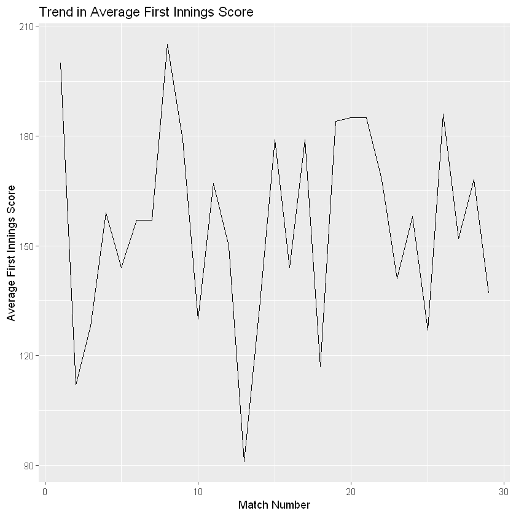

```r
# Creating a sequence of numbers to represent match order
t20_worldcup_copy$match_number <- seq(1, nrow(t20_worldcup_copy))

# Calculating the average first innings score over time (matches)
avg_first_innings_score <- t20_worldcup_copy %>%
arrange(match_number) %>%
group_by(match_number) %>%
summarise(avg_score = mean(first_innings_score))

# Creating a line plot to visualize the trend
ggplot(avg_first_innings_score, aes(x = match_number, y = avg_score)) +
  geom_line() +
  labs(x = "Match Number", y = "Average First Innings Score") +
  ggtitle("Trend in Average First Innings Score")
```

### Result

- I create a new column match_number in the dataset using the seq() function to generate a sequence of numbers from 1 to the number of rows in the dataset. This sequence represents the order of the matches.
- I then proceeded to calculate the average first innings score over time (based on the order of matches) and create a line plot to visualize the trend. The x-axis now represents the "Match Number," which is essentially the order of the matches in the dataset.
- This way, you can analyze the trend in the average first innings score over time

### Comparing the distribution of second innings scores across different stages of the tournament.

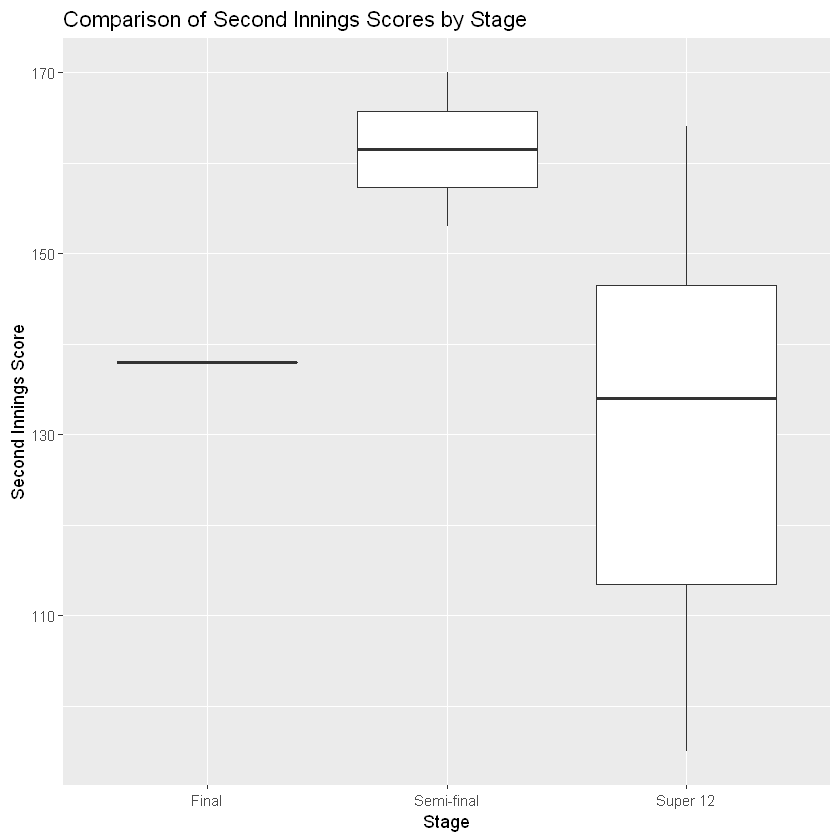

```r
# Creating a box plot to compare second innings scores by stage
ggplot(t20_worldcup_copy, aes(x = stage, y = second_innings_score)) +
  geom_boxplot() +
  labs(x = "Stage", y = "Second Innings Score") +
  ggtitle("Comparison of Second Innings Scores by Stage")
```

### Result

- The teams that progress to the later stages of the tournament are typically the stronger teams.
- The teams have more time to prepare for the later stages of the tournament.
- The pressure is higher in the later stages of the tournament, which can motivate players to perform at their best.

### Venue Analysis:

- Calculating the average first innings score at each venue, to help me identify venues where teams tend to score higher or lower.

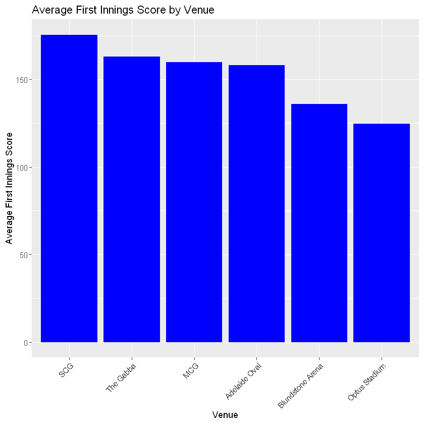

```r
# Calculate the average first innings score by venue
avg_first_innings_score_venue <- t20_worldcup_copy %>%
  group_by(venue) %>%
  summarise(avg_score = mean(first_innings_score))

# Create a bar plot to show average first innings scores at each venue
ggplot(avg_first_innings_score_venue, aes(x = reorder(venue, -avg_score), y = avg_score)) +
  geom_bar(stat = "identity", fill = "blue") +
  labs(x = "Venue", y = "Average First Innings Score") +
  ggtitle("Average First Innings Score by Venue") +
  theme(axis.text.x = element_text(angle = 45, hjust = 1))
```

#### Result

- SCG has the highest average first innings score
- While Optus Stadium has the lowest average first innings score.

###### This suggests that this venue is generally less favorable to batsmen and we can also say some of the factors below can affect the outcome of a match Such as:

- The weather conditions
- The pitch conditions
- And the quality of the opposition.

### Toss Decision Trends

- Calculating the trend in toss decisions (batting or bowling) across different stages of the tournament

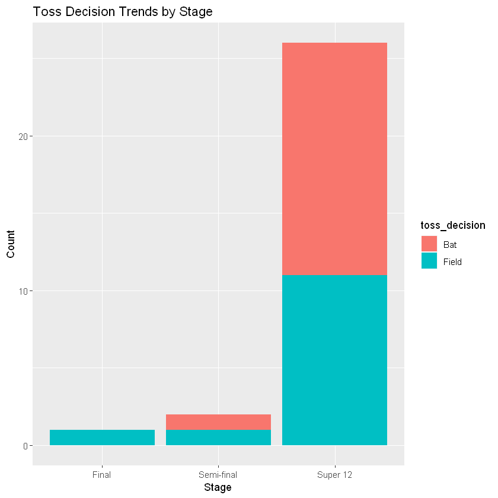

```r
# Creating a stacked bar plot to visualize the trend in toss decisions
toss_decision_trend <- t20_worldcup_copy %>%
  group_by(stage, toss_decision) %>%
  summarise(count = n())

ggplot(toss_decision_trend, aes(x = stage, y = count, fill = toss_decision)) +
  geom_bar(stat = "identity") +
  labs(x = "Stage", y = "Count") +
  ggtitle("Toss Decision Trends by Stage")
```

### Result

###### The graph shows that teams are more likely to choose to bat first in the Super 12 stage than in the Semi-Final and Final stages.

- This suggests that teams value the advantage of batting first in the early stages of the tournament.
- Which makes teams want to get off to a good start in the tournament and build momentum. Another possibility is that teams feel that they have a better chance of winning if they bat first, as this gives them more time to set a target for the opposition.

###### The graph also shows that teams are more likely to choose to field first in the Semi-Final and Final stages of the tournament. Which suggests that teams value the advantage of chasing in the later stages of the tournament